# Assignment 3: Kickstarter Projects

Thomas Brambor

2022-03-24

# Text Mining Kickstarter Projects

```r
print("You will not see the text output.")
```

```r
library(ggplot2)
library(tidyverse)
library(dplyr, warn.conflicts = FALSE)
options(dplyr.summarise.inform = FALSE)
library(plotly)
library(DT)
library(tm)       # Framework for text mining.
getTransformations()
```

```
## [1] "removeNumbers"     "removePunctuation" "removeWords"
## [4] "stemDocument"      "stripWhitespace"
```

```r
library(quanteda) # Another great text mining package
```

```r
library(tidytext) # Text as Tidy Data (good for use with ggplot2)
library(wordcloud)
library(plotrix)
library(ggthemes)
```

## Overview

Kickstarter is an American public-benefit corporation based in Brooklyn, New York, that maintains a global crowd funding platform focused on creativity. The company’s stated mission is to “help bring creative projects to life”.

Kickstarter has reportedly received almost $6 billion in pledges from 20 million backers to fund more than 200,000 creative projects, such as films, music, stage shows, comics, journalism, video games, technology and food-related projects.

For this assignment, I am asking you to analyze the descriptions of kickstarter projects to identify commonalities of successful (and unsuccessful projects) using the text mining techniques we covered in the past two lectures.

## Data

The dataset for this assignment is taken from [webroboto.io ’s repository](https://webrobots.io/kickstarter-datasets/). They developed a scrapper robot that crawls all Kickstarter projects monthly since 2009. I noticed that the most recent crawls appear to be incomplete, so we will take data from the last complete crawl on 2021-05-17.

To simplify your task, I have downloaded the files and partially cleaned the scraped data. In particular, I converted several JSON columns, corrected some obvious data issues, and removed some variables that are not of interest (or missing frequently), and removed some duplicated project entries. I have also subsetted the data to only contain projects with locations set to the United States (to have only English language and USD denominated projects). Some data issues surely remain, so please adjust as you find it necessary to complete the analysis.

The data is contained in the file `kickstarter_projects_2021_05.csv` and contains about 131k projects and about 20 variables.

```r
# Reading in the data
library("readr")
kickstarter <- read_csv("kickstarter_projects_2021-05.csv")
```

## Tasks for the Assignment

### 1. Identifying Successful Projects

#### a) Success by Category

There are several ways to identify success of a project:  
- State (`state`): Whether a campaign was successful or not.  
- Pledged Amount (`pledged`)  
- Achievement Ratio: The variable `achievement_ratio` is calculating the percentage of the original monetary `goal` reached by the actual amount `pledged` (that is `pledged`\`goal` *100).  
- Number of backers (`backers_count`)  
- How quickly the goal was reached (difference between `launched_at` and `state_changed_at`) for those campaigns that were successful.

Use two of these measures to visually summarize which categories were most successful in attracting funding on kickstarter. Briefly summarize your findings.

Below scatter plots show the distribution of backers count and pledged amount for each top category, and the points in purple color represent successful campaign.

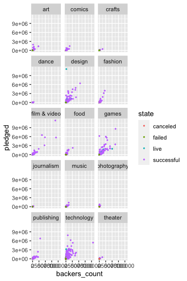

```r
#library(plotly)
q1 <- ggplot(kickstarter, aes(x=backers_count,y= pledged)) +
  geom_point(aes(color = state),size = 0.5) +
  facet_wrap(~top_category,ncol = 3)
q1
```

#### **BONUS ONLY:** b) Success by Location

Now, use the location information to calculate the total number of successful projects by state (if you are ambitious, normalize by population). Also, identify the Top 50 “innovative” cities in the U.S. (by whatever measure you find plausible). Provide a leaflet map showing the most innovative states and cities in the U.S. on a single map based on these information.

1. Calculate the total number of successful projects by state

```r
q1b <- kickstarter %>%
  filter( state %in% c('successful')) %>%
  group_by(location_state) %>%
  summarize(Successful_count = n()) %>%
arrange(desc(Successful_count))

q1b
```

```
## # A tibble: 51 × 2
##    location_state Successful_count
##    <chr>                     <int>
##  1 CA                        14843
##  2 NY                        10245
##  3 TX                         3908
##  4 IL                         2862
##  5 WA                         2819
##  6 FL                         2631
##  7 MA                         2507
##  8 PA                         2438
##  9 OR                         2212
## 10 CO                         1782
## # … with 41 more rows
```

2. I am using the total number of successful project for each city to identify the Top 50 “innovative” cities in the U.S, i.e. the cities ranked top 50 in the total number of successful project.

```r
top50 <- kickstarter %>%
  filter( state %in% c('successful')) %>%
  group_by(location_town) %>%
  summarize(Successful_count_city = n()) %>%
arrange(desc(Successful_count_city))

top50 <- top_n(top50, 50, Successful_count_city)
top50
```

```
## # A tibble: 50 × 2
##    location_town Successful_count_city
##    <chr>                         <int>
##  1 Los Angeles                    5607
##  2 New York                       4996
##  3 Brooklyn                       2248
##  4 Chicago                        2144
##  5 San Francisco                  2085
##  6 Portland                       1765
##  7 Seattle                        1696
##  8 Austin                         1323
##  9 Boston                         1312
## 10 Nashville                      1025
## # … with 40 more rows
```

### 2. Writing your success story

Each project contains a `blurb` – a short description of the project. While not the full description of the project, the short headline is arguably important for inducing interest in the project (and ultimately popularity and success). Let’s analyze the text.

#### a) Cleaning the Text and Word Cloud

To reduce the time for analysis, select the 1000 most successful projects and a sample of 1000 unsuccessful projects (by a metric of your choice). Use the cleaning functions introduced in lecture (or write your own in addition) to remove unnecessary words (stop words), syntax, punctuation, numbers, white space etc. Note, that many projects use their own unique brand names in upper cases, so try to remove these fully capitalized words as well (since we are aiming to identify common words across descriptions).

Create a document-term-matrix.

Provide a word cloud of the most frequent or important words (your choice which frequency measure you choose) among the most successful projects.

- I chose 1000 successful projects from the the ‘successful’ projects with highest 1000 Pledged Amount.
- I chose 1000 unsuccessful projects from the the ‘canceled’ projects with highest 1000 Pledged Amount.

I have first removed the brand name based on `name` column in the the datasets, then applied the cleaning function introduced in lecture + word stem function to clean the `blurb` text.

```r
successful <- filter(kickstarter,state =='successful')
successful1000 <- top_n(successful, 1000, pledged)

unsuccessful <- filter(kickstarter,state =='canceled')
unsuccessful1000 <- top_n(unsuccessful, 1000, pledged)
```

Create a document-term-matrix for 1000 most successful projects:

```r
#remove brand name from blurb
successful1000$blurb <- mapply(function(x,y)gsub(x,"",y) ,gsub(" ", "|",successful1000$name),successful1000$blurb)
unsuccessful1000$blurb <- mapply(function(x,y)gsub(x,"",y) ,gsub(" ", "|",unsuccessful1000$name),unsuccessful1000$blurb)


docs <- Corpus(VectorSource(successful1000$blurb))

removeNumPunct <- function(x){gsub("[^[:alpha:][:space:]]*", "", x)}
clean_corpus <- function(corpus){
  corpus <- tm_map(corpus, removePunctuation)
  # corpus <- tm_map(corpus, content_transformer(removeNumPunct)) # from qdap
  corpus <- tm_map(corpus, content_transformer(tolower))
  # corpus <- tm_map(corpus, content_transformer(replace_symbol)) # from qdap
  corpus <- tm_map(corpus, removeWords, c(stopwords("en")))
    # We could add more stop words as above
  corpus <- tm_map(corpus, removeNumbers)
  corpus <- tm_map(corpus, stripWhitespace)
   corpus <- tm_map(corpus, stemDocument)

  return(corpus)
}

cleaned_successful_blurb <-  clean_corpus(docs)

dtm <- DocumentTermMatrix(cleaned_successful_blurb)
dtm
```

```
## <<DocumentTermMatrix (documents: 1000, terms: 3494)>>
## Non-/sparse entries: 10265/3483735
## Sparsity           : 100%
## Maximal term length: 26
## Weighting          : term frequency (tf)
```

Create a document-term-matrix for 1000 most unsuccessful projects:

```r
docs_unsuccessful1000 <- Corpus(VectorSource(unsuccessful1000$blurb))
cleaned_unsuccessful_blurb <-  clean_corpus(docs_unsuccessful1000)
dtm2 <- DocumentTermMatrix(cleaned_unsuccessful_blurb)
dtm2
```

```
## <<DocumentTermMatrix (documents: 1000, terms: 3657)>>
## Non-/sparse entries: 9986/3647014
## Sparsity           : 100%
## Maximal term length: 34
## Weighting          : term frequency (tf)
```

Create a word cloud for 1000 most successful projects based on word count:

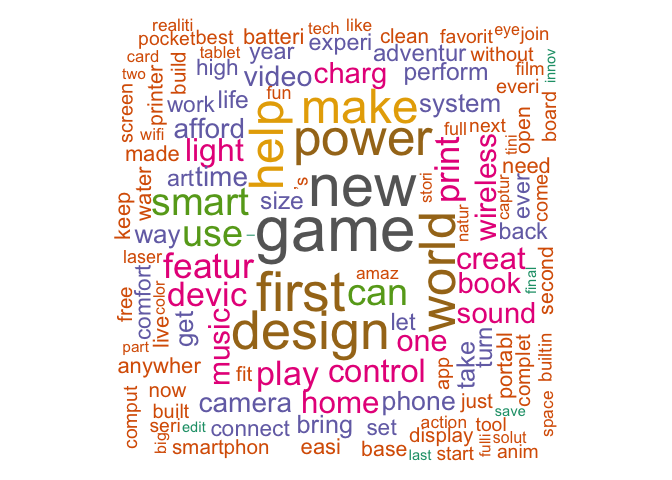

```r
dtm <- TermDocumentMatrix(cleaned_successful_blurb)
m <- as.matrix(dtm)
v <- sort(rowSums(m),decreasing=TRUE)
d <- data.frame(word = names(v),freq=v)

set.seed(1234)
wordcloud(words = d$word, freq = d$freq, min.freq = 1,
          max.words=200, random.order=FALSE, rot.per=0.35,
          colors=brewer.pal(8, "Dark2"))
```

Create a word cloud for 1000 most unsuccessful projects based on word count:

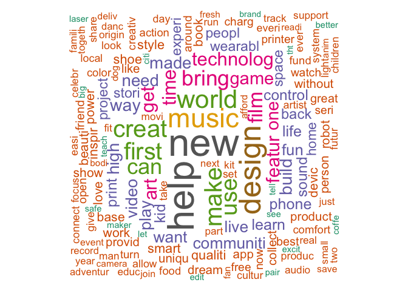

```r
dtm2 <- TermDocumentMatrix(cleaned_unsuccessful_blurb)
m2 <- as.matrix(dtm2)
v2 <- sort(rowSums(m2),decreasing=TRUE)
d2 <- data.frame(word = names(v2),freq=v2)

set.seed(1234)
wordcloud(words = d2$word, freq = d2$freq, min.freq = 1,
          max.words=200, random.order=FALSE, rot.per=0.35,
          colors=brewer.pal(8, "Dark2"))
```

#### b) Success in words

Provide a pyramid plot to show how the words between successful and unsuccessful projects differ in frequency. A selection of 10 - 20 top words is sufficient here.

I followed the following steps to complete this task:

```r
dtm3 <- TermDocumentMatrix(cleaned_successful_blurb)
m3 <- as.matrix(dtm3)
v3 <- sort(rowSums(m3),decreasing=TRUE)
d3 <- data.frame(word = names(v3),freq=v3)
d3$label <- 'successful'

dtm4 <- TermDocumentMatrix(cleaned_unsuccessful_blurb)
m4 <- as.matrix(dtm4)
v4 <- sort(rowSums(m4),decreasing=TRUE)
d4 <- data.frame(word = names(v4),freq=v4)
d4$label <- 'unsuccessful'

merged_count<- merge(d3, d4,
                  by.x =c("word"),
                  by.y=c("word"),all.x=TRUE)

common_word <- top_n(merged_count, 20,freq.x)

top20 <-rbind(filter(d3, d3$word %in% (common_word$word)), filter(d4, d4$word %in% (common_word$word)))

rownames(top20) <- NULL
```

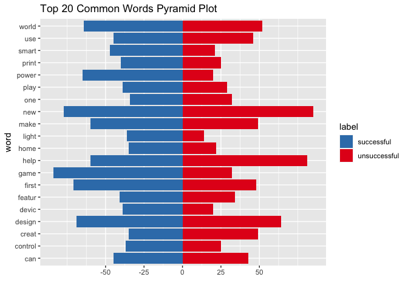

```r
 ggplot(top20, aes(x = word,y = freq, fill = label)) +
  geom_bar(aes(y = -freq),data = filter(top20, label == "successful"), stat='identity')+
  geom_bar(aes(y = freq),data = filter(top20, label == "unsuccessful"), stat='identity')  +
  scale_fill_brewer(palette = "Set1", direction=-1) + coord_flip() +
  scale_y_continuous(breaks = seq(-50, 50, 25)) + ylab("") + coord_flip() +
  ggtitle("Top 20 Common Words Pyramid Plot")
```

#### c) Simplicity as a virtue

These blurbs are short in length (max. 150 characters) but let’s see whether brevity and simplicity still matters. Calculate a readability measure (Flesh Reading Ease, Flesh Kincaid or any other comparable measure) for the texts. Visualize the relationship between the readability measure and one of the measures of success. Briefly comment on your finding.

```r
require(quanteda.textstats)
FRE_blurb <- textstat_readability(kickstarter$blurb,
              measure=c('Flesch.Kincaid'))

q2b <- cbind(FRE_blurb,backers = kickstarter$backers_count,state = kickstarter$state)
#find absolute value of z-score for each value in Flesch.Kincaid
head(q2b)
```

```
##   document Flesch.Kincaid backers      state
## 1    text1      12.835455      28 successful
## 2    text2       1.031111      19     failed
## 3    text3      10.356923      60 successful
## 4    text4       4.383824       0     failed
## 5    text5       6.600000      31 successful
## 6    text6       9.457143      79 successful
```

I analyzed the FK score with number of backers for each project. Based on the distribution below, I found:

1. There are blurb with extremely high FK score, and these projects with high value of FK (hard to read) have low number of backers.
2. There are few projects with large numbers of backers (on the lower right of the graph), indicating more backer prefer easy to read blurb.
3. Most projects that has backers are having FK score lower than 20, indicating easy to read blurb attract more backers.

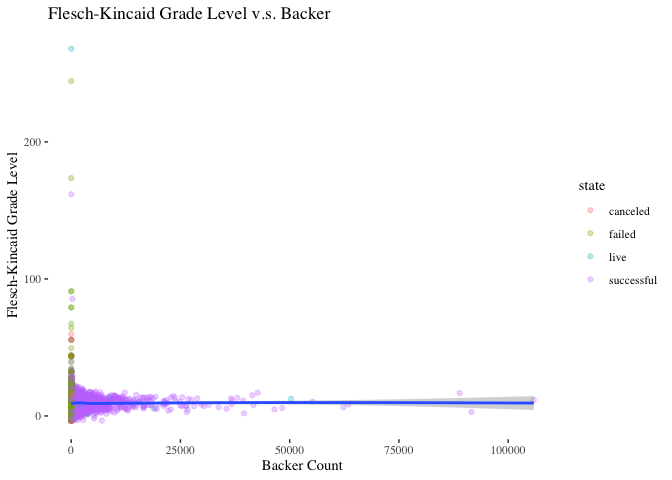

```r
# Plot with added information
ggplot(data=q2b, aes(x=backers,y=Flesch.Kincaid)) +
  geom_point(alpha = 0.3,
             aes(col = state)) +
  geom_smooth() +
  guides(size=FALSE) + theme_tufte() +
  xlab("Backer Count") + ylab("Flesch-Kincaid Grade Level") + ggtitle("Flesch-Kincaid Grade Level v.s. Backer")
```

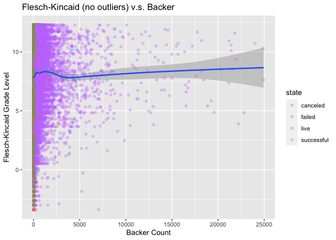

```r
q2b_no_outliers <- transform(q2b, FK = as.numeric(Flesch.Kincaid)) %>% drop_na(Flesch.Kincaid)  %>%
  mutate(zscore = abs(Flesch.Kincaid -mean(Flesch.Kincaid)/sd(Flesch.Kincaid)))   %>% filter(zscore <=10) %>% filter(backers <=25000)

ggplot(data=q2b_no_outliers, aes(x=backers,y=Flesch.Kincaid)) +
  geom_point(alpha = 0.3, aes(col = state)) +
  geom_smooth() +
  xlab("Backer Count") + ylab("Flesch-Kincaid Grade Level") + ggtitle("Flesch-Kincaid (no outliers) v.s. Backer")
```

### 3. Sentiment

Now, let’s check whether the use of positive / negative words or specific emotions helps a project to be successful.

#### a) Stay positive

Calculate the tone of each text based on the positive and negative words that are being used. You can rely on the Hu & Liu dictionary provided in lecture or use the Bing dictionary contained in the tidytext package (`tidytext::sentiments`). Visualize the relationship between tone of the document and success. Briefly comment.

I randomly selected 2000 blurb from the orginal data. Then cleaned these 2000 blurbs: to lower, remove special characters and stop words.

```r
# clean the blurb
#text <- na.omit(kickstarter$blurb)
selected_data <- sample_n(kickstarter,2000)
text <-selected_data$blurb

text <- tolower(text)
text <- gsub("@\\w+", "", text)
text <- gsub("https?://.+", "", text)
text <- gsub("\\d+\\w*\\d*", "", text)
text <- gsub("#\\w+", "", text)
text <- gsub("[^\x01-\x7F]", "", text)
text <- gsub("[[:punct:]]", " ", text)
text <- gsub("\n", " ", text)
text <- gsub("^\\s+", "", text)
text <- gsub("\\s+$", "", text)
text <- gsub("[ |\t]+", " ", text)

corpus <- iconv(text)
corpus <- Corpus(VectorSource(corpus))

cleaned_blurb <- tm_map(corpus, removeWords, stopwords('english'))
inspect(cleaned_blurb[1:5])
```

```
## <<SimpleCorpus>>
## Metadata:  corpus specific: 1, document level (indexed): 0
## Content:  documents: 5
##
## [1] books dedicated   year
## [2]   high school girl tries  give    loves    fit   reflection comes  life  remind    true self
## [3] tawaho   app developed  help professionals  learn  grow   innovative platform
## [4] anything helps  expenses  put   full length album  extensive recording mixing mastering graphic design licensing etc
## [5] apollo command module medical kit
```

Then I conducted sentimental analysis for each selected blurb:

```r
# Sentiment Analysis
pos <- read.table("data/dictionaries/positive-words.txt", as.is=T)
neg <- read.table("data/dictionaries/negative-words.txt", as.is=T)

sentiment <- function(words=c("really great good stuff bad")){
  require(quanteda)
  tok <- quanteda::tokens(words)
  pos.count <- sum(tok[[1]]%in%pos[,1])
  #cat("\n positive words:",tok[[1]][which(tok[[1]]%in%pos[,1])],"\n")
  neg.count <- sum(tok[[1]]%in%neg[,1])
  #cat("\n negative words:",tok[[1]][which(tok[[1]]%in%neg[,1])],"\n")
  out <- (pos.count - neg.count)/(pos.count+neg.count)
  #cat("\n Tone of Document:",out)
  return(out)
}

sentimental_analysis <- lapply(cleaned_blurb,sentiment)
```

These are the sentiment output:

```r
sentimental_analysis_df <- as.data.frame(do.call(rbind, sentimental_analysis))
sent_res <- cbind(selected_data,sentiment = sentimental_analysis_df$V1)

sent_res <- within(sent_res, {
  sentiment_cat <- NA # need to initialize variable
  sentiment_cat[sentiment < 0] <- "Negative"
  sentiment_cat[sentiment == 0] <- "Neutral"
  sentiment_cat[sentiment >0] <- "Positive"
  sentiment_cat[sentiment == 'NaN'] <- "Neutral"
   } )
datatable(sent_res[,c('blurb','sentiment_cat','sentiment')], class = 'cell-border stripe', colnames = c('blurb','sentiment_cat','sentiment'))
```

|  | blurb | sentiment_cat | sentiment |
| --- | --- | --- | --- |
| 1 | 3 Books Dedicated to the Year 2020 | Positive | 1 |
| 2 | When a high school girl tries to give up what she loves so as to fit in, her reflection comes to life to remind her of her true self. | Positive | 1 |
| 3 | TAWAHO is an app developed to help professionals to learn and grow through our innovative platform. | Positive | 1 |
| 4 | Anything Helps. The expenses to put out a full length album are extensive. Recording, mixing, mastering, graphic design, licensing, etc | Neutral |  |
| 5 | Apollo Command Module Medical Kit | Neutral |  |
| 6 | This is a story about a family trying to survive but this isn’t a Zombie fantasy this is real, the world after math of a pandemic. | Negative | -1 |
| 7 | Our goal is to make an audio video studio so we can create an animated Cyber punk rock band. | Negative | -1 |
| 8 | I am taking what others may consider trash and making a work of art that can be loved again. | Positive | 0.333333333333333 |
| 9 | How a cruel joke was handed to us because a woman pretended to be pregnant to gain attention and money for 9 months. | Negative | -0.333333333333333 |
| 10 | A speed-focused hardcore puzzle game inspired by Japanese puzzle games from the late 90's - an homage to "y2k"-era design! | Positive | 1 |

[output cut: 1990 more lines]

I analyzed the relationship between tone of the document and success using the categorized sentiment score (positive, neutral and positive) and state (success, failed, live, canceled).

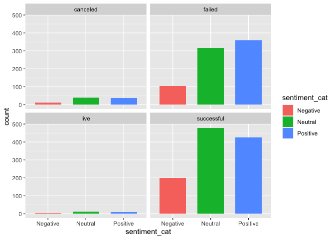

```r
ggplot(data = sent_res, aes(x=sentiment_cat, fill=sentiment_cat)) +
  geom_bar(width=0.7) +
  facet_wrap(~state)
```

#### b) Positive vs negative

Segregate all 2,000 blurbs into positive and negative texts based on their polarity score calculated in step (a). Now, collapse the positive and negative texts into two larger documents. Create a document-term-matrix based on this collapsed set of two documents. Generate a comparison cloud showing the most-frequent positive and negative words.

Step 1: Create a document-term-matrix for positive texts:

```r
positive_df <- sent_res %>% filter(sentiment_cat == 'Positive')
negative_df <- sent_res %>% filter(sentiment_cat == 'Negative')

corpus_pos <- iconv(positive_df$blurb)
corpus_pos <- Corpus(VectorSource(corpus_pos))
cleaned_pos_blurb <-  clean_corpus(corpus_pos)
dtm_pos <- DocumentTermMatrix(cleaned_pos_blurb)
dtm_pos
```

```
## <<DocumentTermMatrix (documents: 832, terms: 3370)>>
## Non-/sparse entries: 9239/2794601
## Sparsity           : 100%
## Maximal term length: 34
## Weighting          : term frequency (tf)
```

Step 12: Create a document-term-matrix for negative texts:

```r
negative_df <- sent_res %>% filter(sentiment_cat == 'Negative')

corpus_neg <- iconv(negative_df$blurb)
corpus_neg <- Corpus(VectorSource(corpus_neg))
cleaned_neg_blurb <-  clean_corpus(corpus_neg)
dtm_neg <- DocumentTermMatrix(cleaned_neg_blurb)
dtm_neg
```

```
## <<DocumentTermMatrix (documents: 322, terms: 1850)>>
## Non-/sparse entries: 3491/592209
## Sparsity           : 99%
## Maximal term length: 16
## Weighting          : term frequency (tf)
```

Step 3: Create word cloud comparision:

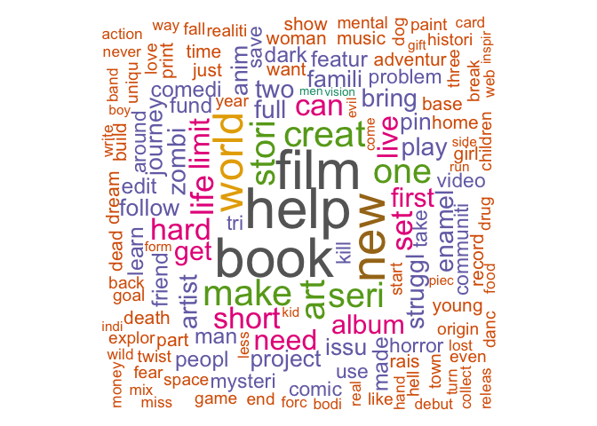

```r
corpus_neg1 <- iconv(negative_df$blurb)
corpus_neg1 <- Corpus(VectorSource(corpus_neg1))
cleaned_neg_blurb1 <-  clean_corpus(corpus_neg1)

dtm_neg <- TermDocumentMatrix(cleaned_neg_blurb1)
m_neg <- as.matrix(dtm_neg)
v_neg <- sort(rowSums(m_neg),decreasing=TRUE)
d_neg <- data.frame(word = names(v_neg),freq=v_neg)

set.seed(1234)
wordcloud(words = d_neg$word, freq = d_neg$freq, min.freq = 1,
          max.words=200, random.order=FALSE, rot.per=0.35,
          colors=brewer.pal(8, "Dark2"))
```

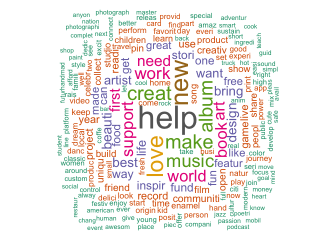

```r
corpus_pos1 <- iconv(positive_df$blurb)
corpus_pos1 <- Corpus(VectorSource(corpus_pos1))
cleaned_pos_blurb1 <-  clean_corpus(corpus_pos1)

dtm_pos <- TermDocumentMatrix(cleaned_pos_blurb1)
m_pos <- as.matrix(dtm_pos)
v_pos <- sort(rowSums(m_pos),decreasing=TRUE)
d_pos <- data.frame(word = names(v_pos),freq=v_pos)

set.seed(1234)
wordcloud(words = d_pos$word, freq = d_pos$freq, min.freq = 1,
          max.words=200, random.order=FALSE, rot.per=0.35,
          colors=brewer.pal(8, "Dark2"))
```

#### c) Get in their mind

Now, use the NRC Word-Emotion Association Lexicon in the `tidytext` package to identify a larger set of emotions (anger, anticipation, disgust, fear, joy, sadness, surprise, trust). Again, visualize the relationship between the use of words from these categories and success. What is your finding?

I used the NRC Word-Emotion Association Lexicon to categorize the sentiment of selected blurbs (2000 from above). The result are in the graph below.

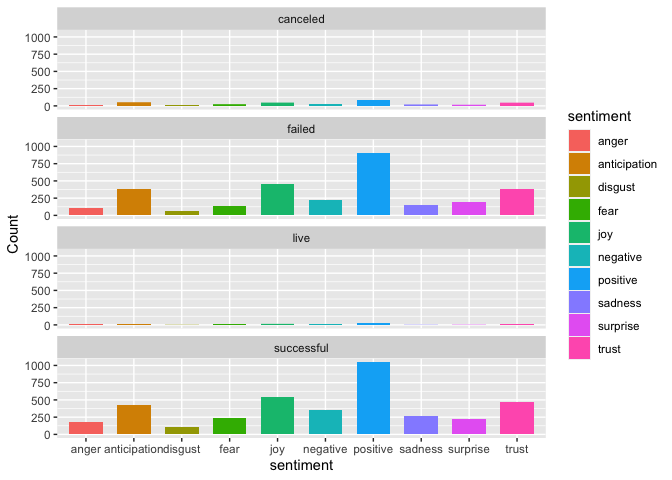

```r
nrc <-  get_sentiments("nrc")

Positive_df <- select(positive_df,c('state','blurb')) %>%
  unnest_tokens(word, blurb) %>%
  inner_join(nrc, by = c("word")) %>%
  group_by(state, sentiment) %>%
  summarize(Count = n())

Negative_df <-select(negative_df,c('state','blurb')) %>%
  unnest_tokens(word, blurb) %>%
  inner_join(nrc, by = c("word")) %>%
  group_by(state, sentiment) %>%
  summarize(Count = n())

combined_df2 <-rbind(Positive_df,Negative_df)

ggplot(data = combined_df2, aes(x=sentiment, y=Count, fill = sentiment)) +
  geom_col(width=0.7) +
  facet_wrap(~state,ncol = 1)
```

Compared to failed projects, the successful project has more sentimental related words (e.g. joy, anticipation, positive, surprise, trust and sadness). This result indicates more sentiment contained in the blurb may relate to higher successful chance of the projects.

## Submission

Please add the hash of your final commit in the feedback pull request to submit your homework. The homework is due on Monday, April 4 at 5pm.

## Please stay honest!

If you do come across something online that provides part of the analysis / code etc., please no wholesale copying of other ideas. We are trying to evaluate your abilities to visualized data not the ability to do internet searches. Also, this is an individually assigned exercise – please keep your solution to yourself.